# Step 2.01: Defining Incident UF from NYULH EHR

Mia Charifson

2024-03-15

The purpose of this document is to summarize the methodology used to derive incident UF diagnosis from the NYU restrospective EHR cohort.

Last updated on 2024-04-18.

# 2.0. Data input & set-up

Load in all tables

```r
pat_cohort <- read.csv('Data/Derived/pat_cohort_w_censoring.csv')
uf_endo <- read.csv('Data/Epic/table3_dx_outcomes.csv')
uf_endo_filled_dates <-read.csv('Data/Epic/fill_missing_dx_dates.csv')
imaging_dx <- read.csv('Data/Epic/table3_dx_imaging.csv')
imaging_orders <- read.csv('Data/Epic/table4_proc_imaging.csv')
surgery_orders <- read.csv('Data/Epic/table4_proc_surgery.csv')
surgery_records <- read.csv('Data/Epic/table4_surgery.csv')
```

Subset tables to the eligible cohort

```r
# Combine tables that need combining
uf_endo_cohort <- uf_endo %>%
  mutate(dx_date = strptime(dx_date, "%Y-%m-%d %H:%M:%S")) %>%
  ## remove those missing a dx date
  filter(!is.na(dx_date)) %>%
  ## add in filled dx_date where missing
  bind_rows(uf_endo_filled_dates %>%
              filter(!is.na(dx_date)) %>%
              mutate(dx_date_filled = strptime(dx_date_filled, "%Y-%m-%d %H:%M:%S"),
                     dx_date = strptime(dx_date, "%Y-%m-%d %H:%M:%S")) %>%
              mutate(dx_date = case_when(is.na(dx_date)~dx_date_filled, TRUE~dx_date),
                     pat_enc_csn_id = as.character(pat_enc_csn_id))) %>%
  # fill in missing index_enc_date
  inner_join(pat_cohort %>% select(pat_id, index_enc_date), by = 'pat_id')

## combine all imaging
imaging_all <- imaging_dx %>%
  mutate(imaging_date = strptime(dx_date, "%Y-%m-%d %H:%M:%S")) %>%
  #mutate(pat_enc_csn_id = as.numeric(pat_enc_csn_id)) %>%
  mutate(event_name = dx_name,
         event_type = paste0('Imaging-', dx_type)) %>%
  select(pat_id, imaging_date, event_name, event_type) %>%
  bind_rows(imaging_orders %>%
              mutate(imaging_date = as.Date(ordering_date)) %>%
              mutate(event_name = procedure_name,
                     event_type = 'Imaging Order') %>%
              select(pat_id, imaging_date, event_name, event_type)) %>%
  filter(pat_id %in% pat_cohort$pat_id)

## combine all surgery
surgery_all <- surgery_records %>%
  mutate(surgery_date = strptime(surgery_date, "%Y-%m-%d %H:%M:%S")) %>%
  full_join(surgery_orders %>% mutate(surgery_date = as.Date(ordering_date)),
            by=c('pat_id', 'pat_enc_csn_id', 'surgery_date', 'procedure_name',
                                 'procedure_code_type', 'procedure_code')) %>%
  mutate(type = ifelse(!is.na(performed), 'Surgery record', 'Surgery order')) %>%
  select(-ordering_date) %>%
  filter(pat_id %in% pat_cohort$pat_id)
```

Verify there are no cases with a Dx prior to index encounter

```r
# there should be no UF/Endo diagnoses prior to their index enc
length(which(uf_endo_cohort$dx_date[uf_endo_cohort$icd10 != 'N80.03'] < uf_endo_cohort$index_enc_date[uf_endo_cohort$icd10 != 'N80.03']))

# look at these patients
#uf_endo_cohort %>% filter(icd10 != 'N80.03' & dx_date <= index_enc_date) %>% View()
```

Collapse to unique dates for each input type (dx, imaging, surgery)

```r
uf_other_codes <- c('D21.9', 'O34.10', 'O34.11', 'O34.12', 'O34.13', 'IMO0001', 'N93.9', 'D28.1', 'O46.8X1')
uf_names <- 'fibroid|leiomyoma|uterine myoma|uterine fibromyoma'

uf_dx_unique <- uf_endo_cohort %>%
  filter(!is.na(dx_date)) %>%
  filter(dx_date <= '2023-08-01') %>% # filter to end of FU
  filter(grepl('D25', icd10) | (icd10 %in% uf_other_codes & grepl(uf_names, tolower(dx_name)))) %>%
  rename(date=dx_date) %>%
  select(-referral_id, -icd10, -dx_date_filled, -pat_enc_csn_id) %>%
  group_by(pat_id, date) %>%
  summarise(event_name = paste0(unique(dx_name), collapse=', '),
            event_type = paste0(unique(dx_type), collapse=', '),
            .groups='drop')

imaging_unique <- imaging_all %>%
  mutate(date=as.Date(imaging_date)) %>%
  group_by(pat_id, date)  %>%
  summarise(event_name = paste0(unique(event_name), collapse=', '),
            event_type = paste0(unique(event_type), collapse=', '),
            .groups='drop')

surgery_unique <- surgery_all %>%
  mutate(date = as.Date(surgery_date)) %>%
  group_by(pat_id, date) %>%
  summarise(event_name = paste0(unique(procedure_name), collapse=', '),
            event_type = paste0(unique(type), collapse=', '),
            .groups='drop')
```

Bind all inputs together

```r
uf_all_long <- bind_rows(uf_dx_unique, imaging_unique, surgery_unique) %>%
  distinct() %>%
  filter(date <= '2023-08-01') %>% # filter to end of FU
  arrange(pat_id, date)

uf_pat_unique <- uf_dx_unique %>% distinct(pat_id)
```

There are 7318 patients who have any UF Dx code added to their EHR at some point during follow-up.

# 2.1. Derive variables related to UF definition

Variable list:

- First diagnosis information: date, type, name, first Dx after partial LTFU (4)
- Diagnosis count information: all, referral, medical_hx, all_medical_hx (4)
- Diagnosis procedure information (for surgical and imaging): ever, confirmed w/in 6 months, confirmed w/ prevalent Dx ever (3x2)
- Meta diagnosis information: any locations, first date of location, ever related to pregnancy (UF only) (3)

*Total number of variables: 17*

## First diagnosis information

Extract variables

```r
uf_first_dx <- uf_endo_cohort %>%
  filter(!is.na(dx_date)) %>%
  filter(dx_date <= '2023-08-01') %>%
  filter(grepl('D25', icd10) | (icd10 %in% uf_other_codes & grepl(uf_names, tolower(dx_name)))) %>%
  group_by(pat_id) %>%
  filter(dx_date==min(dx_date)) %>%
  summarise(first_dx_date = mean(dx_date),
            first_dx_type = paste0(unique(dx_type), collapse = ';'),
            first_dx_name = paste0(unique(dx_name), collapse = ';'),
            .groups='drop') %>%
  left_join(pat_cohort %>%
              select(pat_id, index_enc_date, final_censor_date,
                     final_censor_type, ltfu_status, ltfu_reengage_date)
            , by="pat_id") %>%
  mutate(time_to_first_dx = difftime(first_dx_date, index_enc_date, units="days"),
         dx_after_partial_LTFU = (first_dx_date == ltfu_reengage_date))
```

Plot distribution for date of first diagnosis

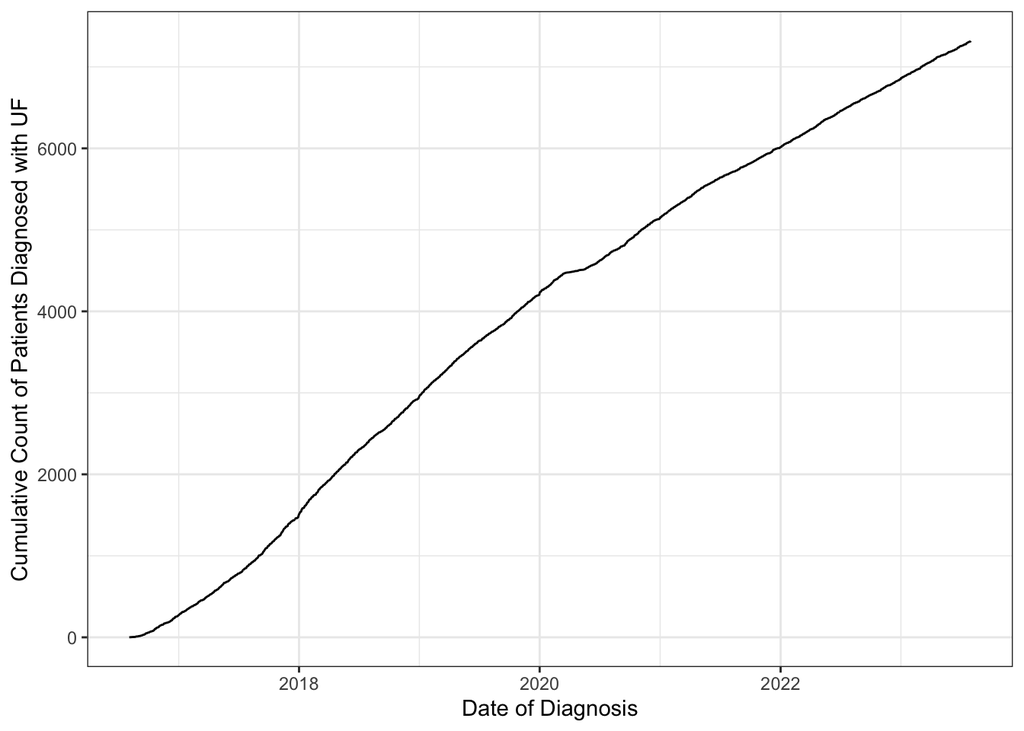

```r
uf_first_dx %>%
  group_by(first_dx_date) %>%
  summarise(count=n(), .groups='drop') %>%
  mutate(cumulative_count = cumsum(count)) %>%
  ggplot(data=., aes(x=first_dx_date, y=cumulative_count)) +
  geom_line() +
  ylab('Cumulative Count of Patients Diagnosed with UF') +
  xlab('Date of Diagnosis') +
  theme_bw()
```

Plot distribution of time to first diagnosis

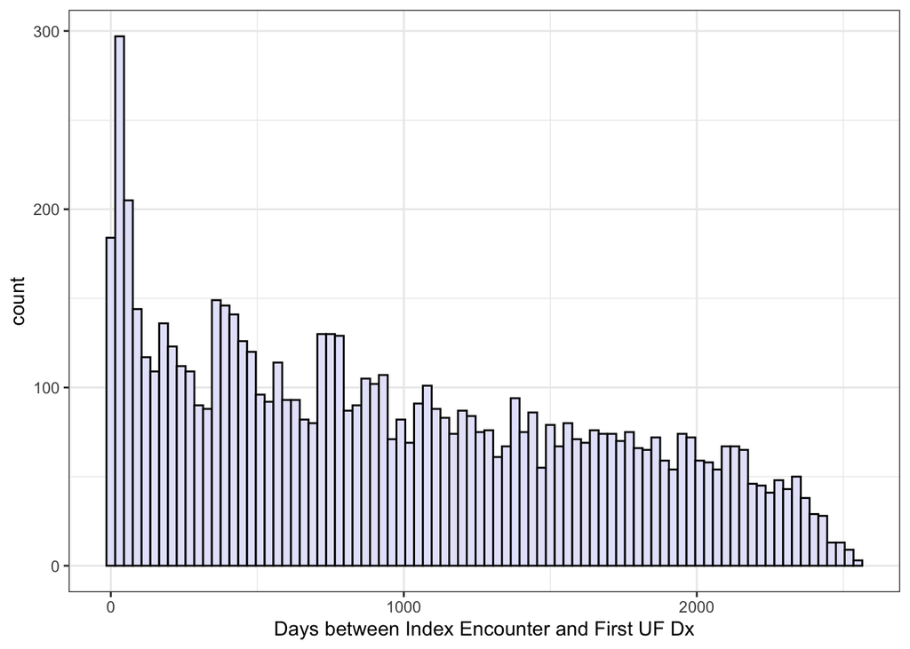

```r
uf_first_dx %>%
  # only for those diagnosed under 6 months
  ggplot(data=., aes(x=time_to_first_dx)) +
  geom_histogram(fill='lavender', color='black', binwidth=30) +
  xlab('Days between Index Encounter and First UF Dx') +
  theme_bw()
```

Table of first diagnosis type

```r
uf_first_dx %>%
  mutate(medical_hx = case_when(grepl('Medical History', first_dx_type)~TRUE, TRUE~FALSE),
         encounter = case_when(grepl('Encounter Diagnosis', first_dx_type)~TRUE, TRUE~FALSE),
         problem_list = case_when(grepl('Problem List', first_dx_type)~TRUE, TRUE~FALSE),
         hospital_dx = case_when(grepl('Hospital Account Diagnosis', first_dx_type)~TRUE, TRUE~FALSE),
         referral_dx = case_when(grepl('Referral Diagnosis', first_dx_type)~TRUE, TRUE~FALSE)) %>%
CreateTableOne(data=., vars = c('referral_dx', 'encounter', 'medical_hx', 'problem_list', 'hospital_dx'))
```

```
##
##                           Overall
##   n                       7318
##   referral_dx = TRUE (%)  2136 (29.2)
##   encounter = TRUE (%)    4632 (63.3)
##   medical_hx = TRUE (%)   2120 (29.0)
##   problem_list = TRUE (%) 1132 (15.5)
##   hospital_dx = TRUE (%)  1064 (14.5)
```

These sum to more than 100% because patients can get one code type dropped on the same day as another (i.e. a referral Dx and an encounter Dx on the same day).

There are 1121 patients diagnosed in their first 6 months of follow-up.

## Diagnosis count variables

Extract diagnosis count variables

```r
uf_dx_count <- uf_dx_unique %>%
  mutate(referral_dx=ifelse(grepl('Referral Diagnosis', event_type), TRUE, FALSE),
         medical_hx=ifelse(event_type == 'Medical History', TRUE, FALSE)) %>%
  group_by(pat_id) %>%
  summarise(dx_count = sum(grepl('Diagnosis|Problem|History', event_type)),
            referral_count = sum(referral_dx),
            all_medical_hx = ifelse(n()==sum(medical_hx), TRUE, FALSE),
            .groups='drop')
```

Plot the distribution of counts of diagnoses

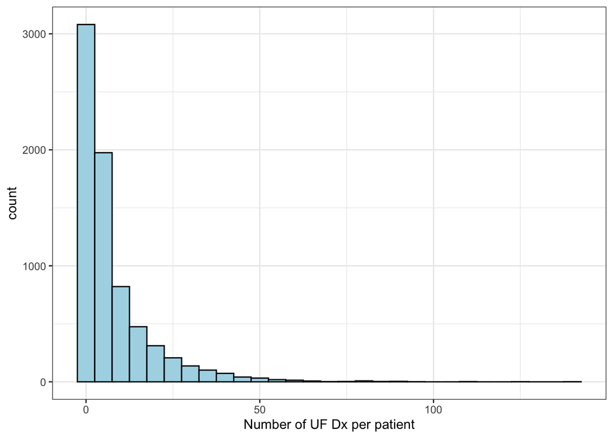

```r
uf_dx_count %>%
  filter(dx_count > 0) %>%
  ggplot(data=., aes(x=dx_count)) +
  geom_histogram(fill='lightblue', color='black', binwidth = 5) +
  xlab('Number of UF Dx per patient') +
  theme_bw()
```

1939 cases have only 1 UF diagnosis code in their records. This is 26% of UF patients. Some of these may be confirmed below via other hints.

Relative frequency of first diagnosis type when they only have one diagnosis code

```r
uf_all_long %>%
  filter(pat_id %in% uf_dx_count$pat_id[which(uf_dx_count$dx_count == 1)]) %>%
  filter(grepl('Diagnosis|History|Problem', event_type)) %>%
  mutate(medical_hx = case_when(grepl('Medical History', event_type)~TRUE, TRUE~FALSE),
         encounter = case_when(grepl('Encounter Diagnosis', event_type)~TRUE, TRUE~FALSE),
         problem_list = case_when(grepl('Problem List', event_type)~TRUE, TRUE~FALSE),
         hospital_dx = case_when(grepl('Hospital Account Diagnosis', event_type)~TRUE, TRUE~FALSE),
         referral_dx = case_when(grepl('Referral Diagnosis', event_type)~TRUE, TRUE~FALSE)) %>%
  CreateTableOne(data=., test=FALSE,
                 vars = c('referral_dx', 'encounter', 'medical_hx', 'problem_list', 'hospital_dx'))
```

```
##
##                           Overall
##   n                       2297
##   referral_dx = TRUE (%)   503 (21.9)
##   encounter = TRUE (%)    1428 (62.2)
##   medical_hx = TRUE (%)    197 ( 8.6)
##   problem_list = TRUE (%)  394 (17.2)
##   hospital_dx = TRUE (%)   587 (25.6)
```

Table showing censoring among those with only one diagnosis code

```r
tab <- uf_first_dx %>%
  filter(pat_id %in% uf_dx_count$pat_id[which(uf_dx_count$dx_count == 1)]) %>%
  filter(first_dx_date > final_censor_date & final_censor_type == 'LTFU') %>%
  mutate(ltfu_status = factor(ltfu_status)) %>%
  CreateTableOne(data=., vars='ltfu_status')

print(tab, showAllLevels=TRUE)
```

```
##
##                   level    Overall
##   n                        19
##   ltfu_status (%) complete 19 (100.0)
```

There are 749 patients for whom the only indication for UF in their EHR is via medical history codes (and no diagnostic procedures). There is a high likelihood these patients are prevalent cases who only had their health history added to their record after entry to cohort.

Assumption: if they were diagnosed outside NYU but during follow-up, they’d have a referral diagnosis code.

Plot age distribution among only medical history cases

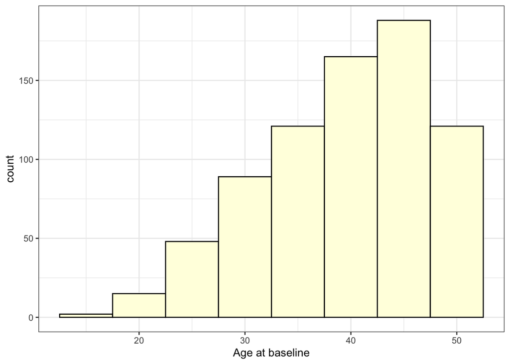

```r
# are these patients generally older
pat_cohort %>%
  filter(pat_id %in% uf_dx_count$pat_id[which(uf_dx_count$all_medical_hx)]) %>%
  ggplot(data=., aes(x=age_20160801)) +
  geom_histogram(fill='lightyellow', color='black', binwidth=5) +
  xlab('Age at baseline') +
  theme_bw()
```

Patients who only ever get UF codes dropped as medical history (and never have any procedures) are predominantly older patients (above 35 years old). I will explore the younger patients but I think in general these patients should be considered prevalent cases and exclude from the analysis.

Look at time to first diagnosis for only medical history cases

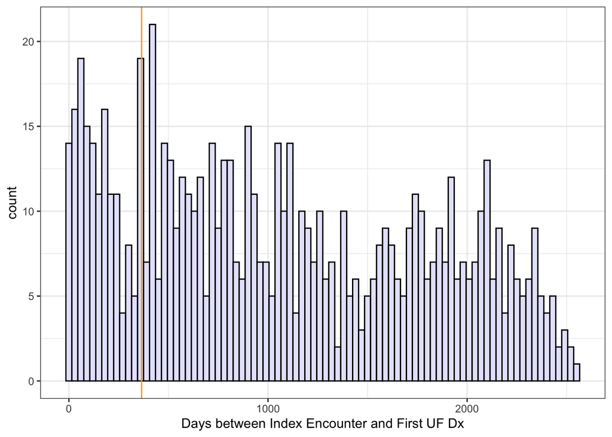

```r
# time to first dx for all medical history cases
uf_first_dx %>%
  filter(pat_id %in% unique(uf_dx_count$pat_id[which(uf_dx_count$all_medical_hx)])) %>%
  ggplot(data=., aes(x=as.numeric(time_to_first_dx))) +
  geom_histogram(fill='lavender', color='black', binwidth=30) +
  xlab('Days between Index Encounter and First UF Dx') +
  geom_vline(xintercept = 365, color='orange') +
  theme_bw()
```

Some of these patients are surely prevalent UF cases based on the early time to first diagnosis, but there is a wide distribution as to the timing of the first diagnoses which implies that some are incident cases that for some reason only get dropped as medical history diagnoses from the start. Assumption: these represent cases diagnosed outside of NYU and then come to NYU after treatment/diagnosis.

## Diagnostic procedure hints

Extract the time between any diagnostic procedure and the closest date of a diagnosis code

```r
procedure_df <- uf_all_long
setDT(procedure_df)
# indexing which rows are procedures
procedure_df$is_procedure <- grepl('Imaging|Surgery', procedure_df$event_type)
# indexing which rows are dx (ignore imaging Dx for now)
procedure_df$is_diagnosis <- grepl('Diagnosis|Problem|List|History', procedure_df$event_type) & !grepl('Imaging',procedure_df$event_type)
# rearrange so if a procedure and dx happen on the same day the procedure goes first
procedure_df <- arrange(procedure_df, pat_id, date, is_diagnosis, is_procedure)
# get the index of the next row that is a dx when the row is a procedure
procedure_df[,next_dx_index:=zoo::na.locf(NA^(!is_diagnosis)*.I, fromLast=T, na.rm=F)*NA^(!is_procedure), by=pat_id]
# find time difference between the date of procedure and the next Dx date
procedure_df <- procedure_df[,next_dx_time_interval:=difftime(date[next_dx_index], date, units="days")]
procedure_df <- procedure_df[,next_dx_name:=event_name[next_dx_index]]
procedure_df <- procedure_df[,next_dx_type:=event_type[next_dx_index]]
# convert to data frame
procedure_df <- as.data.frame(procedure_df) %>%
  mutate(method = case_when(grepl('Surgery', event_type)~"Surgery",
                            grepl('Imaging', event_type)~"Imaging",
                            TRUE~NA),
         confirmed_6months = (as.numeric(next_dx_time_interval)<180),
         confirmed_ever_prevalent = grepl('List|History', next_dx_type))
```

10037 diagnosis codes are on the same date as a procedure.

Plot the time margin distributions by procedure type (imaging vs. surgery)

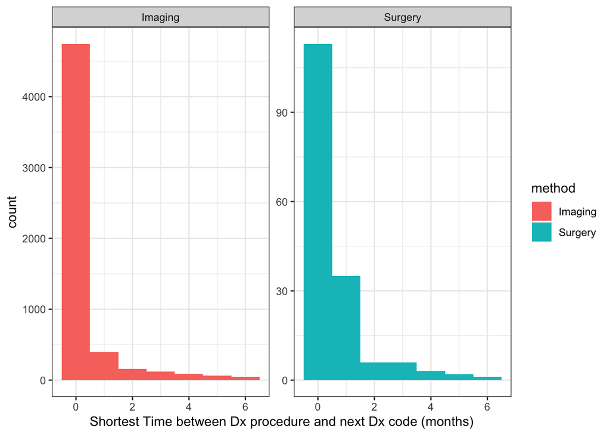

```r
procedure_df %>%
  filter(!is.na(next_dx_time_interval)) %>%
  group_by(pat_id) %>%
  filter(next_dx_time_interval == min(next_dx_time_interval, na.rm=TRUE)) %>%
  # in the case that there are multiple procedures with same margin, take the earlier one
  filter(date == min(date, na.rm=TRUE)) %>%
  filter(next_dx_time_interval < 180) %>%
  ungroup() %>%
  ggplot(data=., aes(x=next_dx_time_interval/30, fill=method)) +
  xlab('Shortest Time between Dx procedure and next Dx code (months)') +
  geom_histogram(binwidth = 1) +
  facet_wrap(~method, scales = 'free_y') +
  theme_bw()
```

The graph shows the count for patients who have an UF Dx, had any diagnostic procedure performed in their EHR, and had another UF Dx code following that procedure. The earliest procedure with the shortest margin between procedure and Dx code are selected per patient. The vast majority have an imaging procedure performed and within one month another Dx code is dropped. For those with a surgical procedure chosen, they are also quickly followed with another Dx code.

Derive final procedure hints for each patients

```r
procedure_hints <- procedure_df %>%
  group_by(pat_id) %>%
  summarise(has_imaging = (sum(method == 'Imaging', na.rm=TRUE)>0),
            has_surgery = (sum(method == 'Surgery', na.rm=TRUE)>0),
            ever_confirmed_6months = (sum(confirmed_6months, na.rm=TRUE)>0),
            prevalent_dx_after_proc = (sum(confirmed_ever_prevalent, na.rm=TRUE)>0),
            imaging_confirmed = (sum(confirmed_6months & method == 'Imaging', na.rm=TRUE)>0),
            surgery_confirmed = (sum(confirmed_6months & method == 'Surgery', na.rm=TRUE)>0),
            first_confirm_date = min(date[which(confirmed_6months)], na.rm=TRUE),
            .groups = 'drop')

## add in first confirmation type
procedure_hints <- procedure_hints %>%
  mutate(first_confirm_date = case_when(is.infinite(first_confirm_date)~NA,
                                             TRUE~first_confirm_date)) %>%
  left_join(procedure_df %>%
              filter(confirmed_6months) %>%
              select(pat_id, method, date),
            by=c('pat_id', 'first_confirm_date' = 'date')) %>%
  group_by(pat_id) %>%
  mutate(first_confirm_type = case_when(n()>1~'both',
                                        TRUE~method)) %>%
  select(-method) %>%
  filter(pat_id %in% uf_pat_unique$pat_id) %>%
  distinct()

#summary(procedure_hints)
#table(procedure_hints$first_confirm_type)
```

Among those who are eventually confirmed, what is the distribution of time to first confirmation (between the first Dx date and the first Dx that was confirmed via imaging/surgery)?

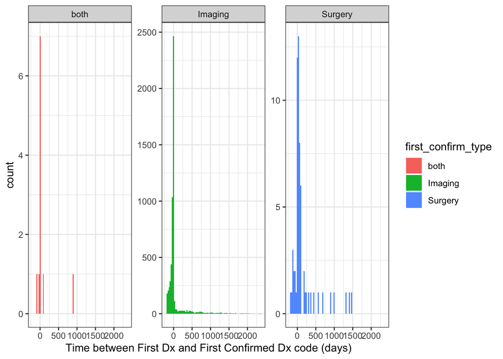

```r
procedure_hints %>%
  left_join(uf_first_dx %>% select(pat_id, first_dx_date), by='pat_id') %>%
  filter(ever_confirmed_6months) %>%
  mutate(time_to_confirmation = difftime(first_confirm_date, first_dx_date, units='days')) %>%
  ggplot(data=., aes(x=time_to_confirmation, fill=first_confirm_type)) +
  xlab('Time between First Dx and First Confirmed Dx code (days)') +
  geom_histogram(binwidth = 30) +
  facet_wrap(~first_confirm_type, scales = 'free_y') +
  theme_bw()
```

```r
procedure_hints %>%
  left_join(uf_first_dx %>% select(pat_id, first_dx_date), by='pat_id') %>%
  filter(ever_confirmed_6months) %>%
  mutate(time_to_confirmation = as.numeric(difftime(first_confirm_date, first_dx_date, units='days'))) %>%
  CreateTableOne(vars='time_to_confirmation', strata = 'first_confirm_type', data=.)
```

```
##                                   Stratified by first_confirm_type
##                                    both           Imaging
##   n                                   11           5686
##   time_to_confirmation (mean (SD)) 81.46 (278.05) 48.10 (280.39)
##                                   Stratified by first_confirm_type
##                                    Surgery         p      test
##   n                                    63
##   time_to_confirmation (mean (SD)) 154.57 (355.73)  0.011
```

## Meta-diagnosis information

Location of the fibroid & first date of first location Dx

```r
# extract location of the UF based on Dx name if that exists
uf_loc_names <- 'intramural|subserous|submucosal|subserosal|submucous|cervix|cervical'
location_df <- procedure_df %>%
  filter(grepl('History|List|Diagnosis', event_type) & !grepl('Imaging', event_type)) %>%
  mutate(location = (grepl(uf_loc_names, tolower(event_name)))) %>%
  group_by(pat_id) %>%
  arrange(date) %>%
  summarise(any_location = (sum(location)>0),
            first_location_date = first(date[which(location)])) %>%
  filter(pat_id %in% uf_pat_unique$pat_id)
## add to other hints
other_hints <- uf_pat_unique %>%
  left_join(location_df,  by='pat_id')
```

Ever related to pregnancy (UF only)

```r
# extract location of the UF based on Dx name if that exists
uf_pregnancy <- 'pregnancy|partum|antenatal|antepartum'
procedure_df$pregnancy_related <- (!grepl("History", procedure_df$event_type) &
                                        grepl(uf_pregnancy, tolower(procedure_df$event_name)))
# join to other hints
other_hints <- other_hints %>%
  left_join(procedure_df %>%
              group_by(pat_id) %>%
              summarise(ever_pregnancy_related = (sum(pregnancy_related)>0)),
            by='pat_id')
```

Historical diagnosis close to fist diagnosis date

```r
## grab hx codes and record first instance
uf_hx_code <- uf_endo_cohort %>%
  filter(grepl('Z86', icd10)) %>%
  group_by(pat_id) %>%
  summarise(first_hx_code = min(dx_date), .groups='drop') %>%
  inner_join(uf_first_dx %>% select(pat_id, first_dx_date, first_dx_type, first_dx_name),
             by='pat_id') %>%
  mutate(hx_code_margin = difftime(first_hx_code, first_dx_date, unit='days'),
         confident_prevalent = (hx_code_margin<=60))

# join to other hints
other_hints <- other_hints %>%
  left_join(uf_hx_code %>% select(pat_id, confident_prevalent),
            by='pat_id')
```

# 2.2. Heatmap of UF outcome hints

There are several “hints” in the EHR which might encourage confidence that a UF Dx is a true positive. They were extracted from the EHR above. Understanding how they relate to each other in our cohort can be informative of how to identify confident incident and prevalent cases.

```r
# subset to only those with a UF dx
uf_dx_hints <- uf_first_dx %>%
  select(pat_id, contains('first'), dx_after_partial_LTFU) %>%
  left_join(uf_dx_count, by='pat_id') %>%
  left_join(procedure_hints, by='pat_id') %>%
  left_join(other_hints, by='pat_id') %>%
  mutate(across(is_logical, ~ifelse(is.na(.), FALSE, .)),
         time_to_first_dx = as.numeric(time_to_first_dx),
         multiple_referral = (referral_count >= 2),
         multiple_dx = (dx_count >= 2),
         first_dx_medical = grepl('Medical History', first_dx_type))
names(uf_dx_hints)
```

```
##  [1] "pat_id"                  "first_dx_date"
##  [3] "first_dx_type"           "first_dx_name"
##  [5] "time_to_first_dx"        "dx_after_partial_LTFU"
##  [7] "dx_count"                "referral_count"
##  [9] "all_medical_hx"          "has_imaging"
## [11] "has_surgery"             "ever_confirmed_6months"
## [13] "prevalent_dx_after_proc" "imaging_confirmed"
## [15] "surgery_confirmed"       "first_confirm_date"
## [17] "first_confirm_type"      "any_location"
## [19] "first_location_date"     "ever_pregnancy_related"
## [21] "confident_prevalent"     "multiple_referral"
## [23] "multiple_dx"             "first_dx_medical"
```

```r
# only add up hints for incident cases
bin_hints <- c('dx_after_partial_LTFU', 'has_imaging', 'has_surgery', 'ever_confirmed_6months',
               'prevalent_dx_after_proc', 'imaging_confirmed', 'surgery_confirmed', 'any_location',
               'ever_pregnancy_related', 'multiple_referral')
uf_dx_hints <- uf_dx_hints %>%
  mutate(number_pos_hints = rowSums(.[bin_hints], na.rm=TRUE)) %>%
  mutate(confident_incident = case_when(confident_prevalent~FALSE,
                                        ever_confirmed_6months~TRUE,
                                        any_location~TRUE,
                                        ever_pregnancy_related~TRUE,
                                        prevalent_dx_after_proc~TRUE,
                                        dx_after_partial_LTFU~TRUE,
                                        multiple_referral~TRUE,
                                        TRUE~FALSE))
```

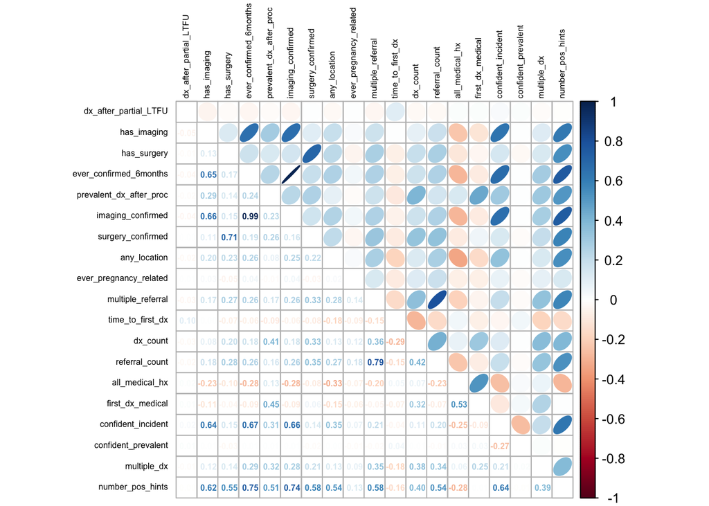

```r
all_hints <- c(bin_hints, 'time_to_first_dx', 'dx_count', 'referral_count', 'all_medical_hx', 'first_dx_medical',
               'confident_incident', 'confident_prevalent', 'multiple_dx', 'number_pos_hints')
corrplot.mixed(cor(uf_dx_hints[,c(all_hints)],
                   use='pairwise.complete.obs'),  # Correlation matrix
               lower = "number",
               upper = "ellipse",
               tl.cex=0.5,
               number.cex=0.5,
               tl.pos = "lt",
               tl.col = "black")
```

The correlation plot above visualizes the correlation between these binary UF diagnosis characteristics. The number of positive hints is a count of how many of the hints we believe to be predictive of incident case Dx appear in their EHR. I interpret strong positive associations as indicative of characteristics that are most common among cases with an abundance of EHR data pointing it to be an incident case.

NOTE: it is important to note that this is inflated for certain characteristics such as `ever_confirmed_6months`, which by definition also requires a procedure and a confirmed procedure (so at a minimum when `ever_confirmed_6months = TRUE`, `number_pos_hints = 3`). **For this reason, number of hints alone cannot be used to define confident cases, but is just used here to explore how these EHR data variables relate to each other.**

Distribution of positive hints (split by whether `ever_confirmed_6months`)

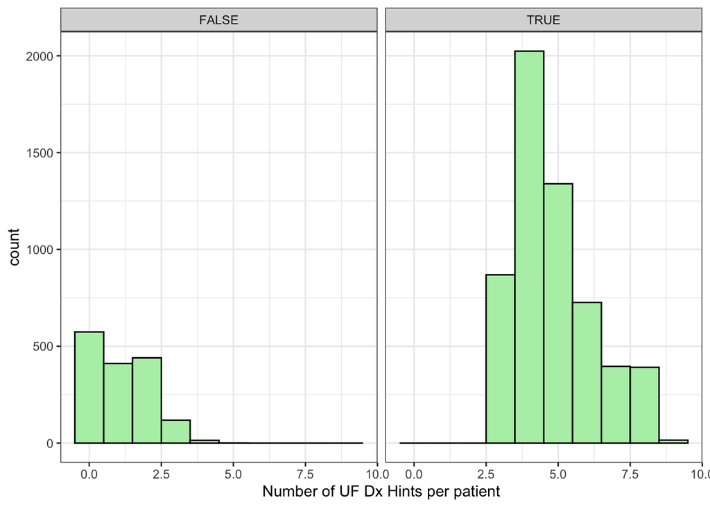

```r
uf_dx_hints %>%
  ggplot(data=., aes(x=number_pos_hints)) +
  geom_histogram(fill='darkseagreen2', color='black', binwidth=1) +
  facet_grid(~ever_confirmed_6months) +
  xlab('Number of UF Dx Hints per patient') +
  theme_bw()
```

```r
# check for duplicates
paste0('N duplicate patient IDs: ', length(which(duplicated(uf_dx_hints$pat_id))))
```

```
## [1] "N duplicate patient IDs: 0"
```

```r
# make sure all confirmations are within 180 days prior to first dx code
paste0('N confirmation date >6 months before first dx date: ', length(which(difftime(uf_dx_hints$first_dx_date, uf_dx_hints$first_confirm_date, units='days') > 180))
       )
```

```
## [1] "N confirmation date >6 months before first dx date: 0"
```

```r
# make sure all location dates are not earlier
paste0('N location date before first dx date: ',
length(which(uf_dx_hints$first_dx_date > uf_dx_hints$first_location_date)))
```

```
## [1] "N location date before first dx date: 0"
```

```r
# check how many have location on the first date of diagnosis and no procedure
## these could be potentially prevalent diagnoses
paste0('N location date on same day as first dx date but no confirmation: ',
length(which(uf_dx_hints$first_dx_date == uf_dx_hints$first_location_date &
               (uf_dx_hints$first_confirm_date > uf_dx_hints$first_dx_date |
                  is.na(uf_dx_hints$first_confirm_date)))))
```

```
## [1] "N location date on same day as first dx date but no confirmation: 590"
```

```r
# check how many are confirmed and then first diagnosis code happens
paste0('N confirmed before or on first dx date: ',
       uf_dx_hints %>%
         filter(first_dx_date == first_confirm_date |
                  difftime(first_dx_date, first_confirm_date, units='days') < 180) %>%
  nrow())
```

```
## [1] "N confirmed before or on first dx date: 5760"
```

```r
# check how many are confirmed and then first diagnosis code happens
paste0('N with only one billing diagnosis: ',
       uf_dx_hints %>% filter(dx_count == 1 & grepl('Hospital', first_dx_type)) %>% nrow())
```

```
## [1] "N with only one billing diagnosis: 548"
```

```r
# look into those with location on first dx date but no form of confirmation on same date
uf_dx_hints %>%
  filter(first_location_date==first_dx_date & (first_confirm_date > first_dx_date | is.na(first_confirm_date))) %>%
  left_join(pat_cohort %>% select(pat_id, pat_mrn_id), by ='pat_id') %>%
  select(pat_mrn_id, pat_id:confident_incident) %>%
  View()

# look into those with only one billing diagnosis ever
uf_dx_hints %>%
  filter(dx_count == 1 & grepl('Hospital', first_dx_type)) %>%
  left_join(pat_cohort %>% select(pat_id, pat_mrn_id), by ='pat_id') %>%
  select(pat_mrn_id, pat_id:confident_incident) %>%
  View()
```

# 2.3. Define UF outcome according to EHR phenotypes

`Confident positive` is defined as a UF diagnosis which has some combination of the following hints (in order of confidence):

1. Confirmation of UF Dx following a diagnostic procedure (same day as procedure = most confident)

*Assumption: if a provider drops a diagnosis code within 6 months after diagnostic procedure, the procedure was confirmatory to the presence of fibroids.*

2. Having a diagnostic procedure & any UF Dx after a diagnostic procedure

*Assumption: diagnosis was confirmed during surgery but no code was dropped (either it was treated or presumed resolved, simply missed in coding), later the fibroids are entered into EHR as a historical diagnosis or on problem list*

3. Having location of the fibroid indicated on a diagnosis

*Assumption: the only way a location would be supplied is through some diagnostic procedure even if not noted in their charts.*

4. Pregnancy-related diagnoses

*Assumption: most of these are incidental fibroid diagnoses resulting from imaging related to pregnancy (confirmed by Shilpi). Many of these cases may be asymptomatic but are true incidental cases.*

5. 2 or more referral diagnoses

*Assumption: if patients are being referred multiple times for UF – this could indicate that they have strong symptomology and/or they are diagnosed by an external provider and then referred to NYU for treatment.*

6. First diagnosis is on the same date as re-engage after LTFU

*Assumption: Patients who receive their first UF Dx on the day they return to relevant care at NYU were likely diagnosed outside of NYU and return to NYU with the new incident diagnosis.*

QUESTION: Should patients diagnosed DURING partial LTFU be included here? Based on dicussion with Anais, these could be encounter diagnoses dropped for the referral (forced by Epic) but is not a confirmed diagnosis.

`Prevalent cases` can be identified via a historical diagnosis (Z86) code at or close (within 2 months) to first dx code

*Assumption: If within two months of the first dx code they also get a code that indicates ‘history of endometriosis’ there is a good chance that the first diagnosis code was for a prevalent diagnosis.*

# 2.4. Determine final case status

## Confident incident cases

```r
print(CreateTableOne(data=uf_dx_hints %>% filter(confident_incident), includeNA=TRUE,
               vars=c('ever_confirmed_6months', 'any_location',
                      'prevalent_dx_after_proc','ever_pregnancy_related', 'multiple_referral',
                      'dx_after_partial_LTFU')),
      showAllLevels = TRUE)
```

```
##
##                               level Overall
##   n                                 6391
##   ever_confirmed_6months (%)  FALSE  691 (10.8)
##                               TRUE  5700 (89.2)
##   any_location (%)            FALSE 2807 (43.9)
##                               TRUE  3584 (56.1)
##   prevalent_dx_after_proc (%) FALSE 3210 (50.2)
##                               TRUE  3181 (49.8)
##   ever_pregnancy_related (%)  FALSE 6123 (95.8)
##                               TRUE   268 ( 4.2)
##   multiple_referral (%)       FALSE 4564 (71.4)
##                               TRUE  1827 (28.6)
##   dx_after_partial_LTFU (%)   FALSE 6352 (99.4)
##                               TRUE    39 ( 0.6)
```

## Hesitant cases (prevalent or incident)

```r
# subset to cases who are not confident_incident
df_not_confident <- uf_dx_hints %>%
  filter(!confident_incident) %>%
  mutate(only_one_code=ifelse(dx_count==1, TRUE, FALSE)) %>%
  mutate(dx_early_into_FU = ifelse(time_to_first_dx <= 180, TRUE, FALSE))

# look at overall characteristics
prevalent_vars = c("first_dx_medical", "time_to_first_dx", "dx_count", "all_medical_hx", "has_surgery",
                   "has_imaging", "only_one_code")
tab_not_confident <- CreateTableOne(data=df_not_confident, vars=prevalent_vars)

print(tab_not_confident,nonnormal="dx_count", showAllLevels = TRUE)
```

```
##
##                                level Overall
##   n                                      927
##   first_dx_medical (%)         FALSE     558 (60.2)
##                                TRUE      369 (39.8)
##   time_to_first_dx (mean (SD))       1043.12 (705.12)
##   dx_count (median [IQR])               1.00 [1.00, 5.00]
##   all_medical_hx (%)           FALSE     647 (69.8)
##                                TRUE      280 (30.2)
##   has_surgery (%)              FALSE     874 (94.3)
##                                TRUE       53 ( 5.7)
##   has_imaging (%)              FALSE     591 (63.8)
##                                TRUE      336 (36.2)
##   only_one_code (%)            FALSE     461 (49.7)
##                                TRUE      466 (50.3)
```

```r
#procedure_df %>% filter(pat_id %in% df_not_confident$pat_id[which(df_not_confident$has_imaging)]) %>% arrange(pat_id) %>% View()
```

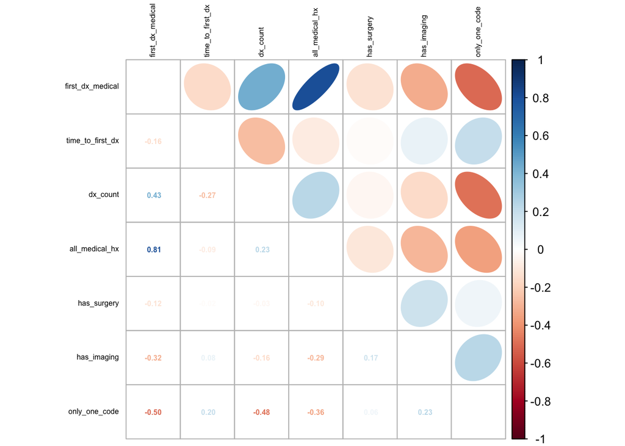

```r
corrplot.mixed(cor(df_not_confident[,prevalent_vars], use='pairwise.complete.obs'),
               lower = "number",
               upper = "ellipse",
               tl.cex=0.5,
               number.cex=0.5,
               tl.pos = "lt",
               tl.col = "black")
```

Based on looking at this correlation matrix, the most relevant characteristics of the non-confident cases appears to be having only one code and the first dx code being a medical history code.

## Investigate censoring among those eventually diagnosed

How many patients are censored prior to their first UF diagnosis code?

Look at censoring date and first diagnosis date for all cases

```r
uf_dx_info <- uf_dx_hints %>%
  left_join(pat_cohort, by='pat_id') %>%
  mutate(final_censor_type= ifelse(final_censor_type == 'LTFU' & ltfu_status == 'partial', NA, final_censor_type),
         final_censor_date= case_when(is.na(final_censor_type)~NA, TRUE~final_censor_date),
         censored_before_dx = case_when(is.na(final_censor_date)~FALSE,
                                        first_dx_date > final_censor_date~TRUE,
                                        TRUE~FALSE))
# print table
CreateTableOne(data=uf_dx_info, strata='confident_incident', var=c('final_censor_type', 'censored_before_dx'),
                 includeNA=TRUE, addOverall = TRUE)
```

```
##                                Stratified by confident_incident
##                                 Overall      FALSE       TRUE         p
##   n                             7318         927         6391
##   final_censor_type (%)                                               <0.001
##      Aged out                    485 ( 6.6)   71 ( 7.7)   414 ( 6.5)
##      Death                         6 ( 0.1)    0 ( 0.0)     6 ( 0.1)
##      LTFU                        815 (11.1)  153 (16.5)   662 (10.4)
##      Menopause                   552 ( 7.5)   62 ( 6.7)   490 ( 7.7)
##      Surgery                     552 ( 7.5)   19 ( 2.0)   533 ( 8.3)
##      NA                         4908 (67.1)  622 (67.1)  4286 (67.1)
##   censored_before_dx = TRUE (%)  228 ( 3.1)   34 ( 3.7)   194 ( 3.0)   0.350
##                                Stratified by confident_incident
##                                 test
##   n
##   final_censor_type (%)
##      Aged out
##      Death
##      LTFU
##      Menopause
##      Surgery
##      NA
##   censored_before_dx = TRUE (%)
```

Look at censoring among those censored before first dx code date

```r
CreateTableOne(data=uf_dx_info %>% filter(censored_before_dx), strata='confident_incident',
               var=c('final_censor_type'), includeNA=TRUE, addOverall = TRUE)
```

```
##                        Stratified by confident_incident
##                         Overall     FALSE      TRUE        p      test
##   n                     228         34         194
##   final_censor_type (%)                                     0.016
##      Aged out            37 (16.2)   4 (11.8)   33 (17.0)
##      LTFU                43 (18.9)  13 (38.2)   30 (15.5)
##      Menopause          143 (62.7)  17 (50.0)  126 (64.9)
##      Surgery              5 ( 2.2)   0 ( 0.0)    5 ( 2.6)
```

```r
# look into those censored due to surgery
procedure_df %>%
  filter(pat_id %in% uf_dx_info$pat_id[which(uf_dx_info$censored_before_dx &
                                        uf_dx_info$final_censor_type == 'Surgery')]) %>%
  View()

uf_dx_info %>% filter(censored_before_dx & final_censor_type == 'LTFU') %>% View()
```

# 2.5. Finalize outcome and save files

Add to patient cohort table with flag for case type: if they are censored before diagnosis (unless it is the surgery_confirmed case) then keep them as censored but otherwise use their first Dx date as their censor date

```r
pat_cohort_uf <- pat_cohort %>%
  left_join(procedure_df %>%
              filter(is_procedure) %>%
              group_by(pat_id) %>%
              summarise(ever_imaging = ifelse(sum(method == 'Imaging')>=1, TRUE, FALSE),
                        ever_surgery = ifelse(sum(method == 'Surgery')>=1, TRUE, FALSE),
                        .groups='drop'),
            by='pat_id') %>%
  left_join(uf_dx_hints %>%
              mutate(putative_group = case_when(confident_incident~'Incident case',
                                                !confident_incident~'Prevalent case or false positive')) %>%
              select(pat_id, first_dx_date, putative_group, first_confirm_date, first_confirm_type,
                     first_location_date),
            by='pat_id') %>%
  mutate(ever_imaging = case_when(is.na(ever_imaging)~FALSE, TRUE~ever_imaging),
         ever_surgery = case_when(is.na(ever_surgery)~FALSE, TRUE~ever_surgery),
         uf_dx = case_when(!is.na(putative_group)~TRUE, TRUE~FALSE),
         uf_before_censor = case_when(is.na(final_censor_date)~TRUE,
                                      first_dx_date <= final_censor_date~TRUE,
                                      TRUE~FALSE),
         final_censor_type_uf_all = case_when(uf_dx & uf_before_censor~'UF case',
                                              uf_dx & final_censor_type==first_confirm_type~'UF case',
                                              TRUE~final_censor_type),
         final_censor_type_uf_confident = case_when(uf_dx & putative_group == 'Incident case' &
                                                   uf_before_censor~'UF case',
                                                   uf_dx & putative_group == 'Incident case' &
                                                     final_censor_type==first_confirm_type~'UF case',
                                                   TRUE~final_censor_type),
         final_censor_date_uf_all = case_when(final_censor_type_uf_all=='UF case'~first_dx_date,
                                              TRUE~as.Date(final_censor_date)),
         final_censor_date_uf_confident = case_when(final_censor_type_uf_confident == 'UF case'~first_dx_date,
                                                    TRUE~as.Date(final_censor_date)))
```

Look at censoring among those censored before first dx code date

```r
CreateTableOne(data=pat_cohort_uf, strata='uf_dx', includeNA=TRUE, addOverall = TRUE,
               var=c('final_censor_type_uf_all', 'final_censor_type_uf_confident'))
```

```
##                                     Stratified by uf_dx
##                                      Overall       FALSE         TRUE
##   n                                  82090         74772         7318
##   final_censor_type_uf_all (%)
##      Aged out                         3537 ( 4.3)   3500 ( 4.7)    37 ( 0.5)
##      Death                              38 ( 0.0)     38 ( 0.1)     0 ( 0.0)
##      LTFU                            19654 (23.9)  19611 (26.2)    43 ( 0.6)
##      Menopause                        2773 ( 3.4)   2630 ( 3.5)   143 ( 2.0)
##      Surgery                           323 ( 0.4)    318 ( 0.4)     5 ( 0.1)
##      UF case                          6974 ( 8.5)      0 ( 0.0)  6974 (95.3)
##      NA                              48791 (59.4)  48675 (65.1)   116 ( 1.6)
##   final_censor_type_uf_confident (%)
##      Aged out                         3604 ( 4.4)   3500 ( 4.7)   104 ( 1.4)
##      Death                              38 ( 0.0)     38 ( 0.1)     0 ( 0.0)
##      LTFU                            19794 (24.1)  19611 (26.2)   183 ( 2.5)
##      Menopause                        2818 ( 3.4)   2630 ( 3.5)   188 ( 2.6)
##      Surgery                           342 ( 0.4)    318 ( 0.4)    24 ( 0.3)
##      UF case                          6091 ( 7.4)      0 ( 0.0)  6091 (83.2)
##      NA                              49403 (60.2)  48675 (65.1)   728 ( 9.9)
##                                     Stratified by uf_dx
##                                      p      test
##   n
##   final_censor_type_uf_all (%)       <0.001
##      Aged out
##      Death
##      LTFU
##      Menopause
##      Surgery
##      UF case
##      NA
##   final_censor_type_uf_confident (%) <0.001
##      Aged out
##      Death
##      LTFU
##      Menopause
##      Surgery
##      UF case
##      NA
```

Calculate person-time for cohort (including all cases)

```r
pat_cohort_uf %>%
  mutate(person_years = case_when(is.na(final_censor_date_uf_all)~difftime('2023-08-01',
                                                                           index_enc_date,units='days'),
                                  TRUE~difftime(final_censor_date_uf_all,index_enc_date,units='days')),
         person_years = as.numeric(person_years)/365.25) %>%
  summarise(total_person_time = sum(person_years),
            n_cases = sum(final_censor_type_uf_all == 'UF case', na.rm=TRUE),
            uf_incidence_rate = sum(uf_dx)/sum(person_years)*10000)
```

```
##   total_person_time n_cases uf_incidence_rate
## 1          388944.4    6974          188.1503
```

Calculate person-time for cohort (only confident cases)

```r
pat_cohort_uf %>%
  filter(putative_group != 'Prevalent case or false positive' | is.na(putative_group)) %>%
  mutate(person_years = case_when(is.na(final_censor_date_uf_confident)~difftime('2023-08-01',
                                                                           index_enc_date,units='days'),
                                  TRUE~difftime(final_censor_date_uf_confident,index_enc_date,units='days')),
         person_years = as.numeric(person_years)/365.25) %>%
  summarise(total_person_time = sum(person_years),
            n_cases = sum(final_censor_type_uf_confident == 'UF case', na.rm=TRUE),
            uf_incidence_rate = sum(uf_dx & putative_group == 'Incident case')/sum(person_years)*10000)
```

```
##   total_person_time n_cases uf_incidence_rate
## 1          386395.8    6091          165.4003
```

Save both dataframes (updated pat_cohort & all_uf_hints)

```r
write.csv(uf_dx_hints, 'Data/Derived/uf_all_hints.csv', row.names=FALSE)
write.csv(pat_cohort_uf, 'Data/Derived/Chapter 1/cohort_w_uf.csv', row.names=FALSE)
```